# Data visualisation - r4ds

2019-03-15

## データ可視化

> シンプルなグラフはいかなる道具よりもdata analystに情報をもたらす。  
> 絵が最大の価値を持つのは全く想定していなかったものに気付かされる時である。  
> –John Tukey

### ggplot2

- グラフィックを扱うための言語 **Grammer of graphics** を使うためのライブラリ
- 慣れるまでに時間がかかるけど、一度使うと離れられない

### [神の論文](http://vita.had.co.nz/papers/layered-grammar.pdf)

余裕があるときにどうぞ

## 準備

```r
install.packages("tidyverse")
library(tidyverse)
```

### `tidyverse`とは

- Hadley神が作ったHadley宇宙
  - `ggplot2`も含んだライブラリ群が一括ロードされる

### 復習

- `install.packages`は一回だけ
- `library`は起動のたびに

## データフレーム

- 各列には変数が、各行は観測が収められている
- Rで分析するデータの**基本形**
  - 「すべて対象はdata.frame」の気持ちで構わない

```r
mpg
#># A tibble: 234 x 11
```

```
#>  manufacturer model displ  year   cyl trans drv     cty   hwy fl
#>  <chr>        <chr> <dbl> <int> <int> <chr> <chr> <int> <int> <chr>
#>  1 audi         a4      1.8  1999     4 auto… f        18    29 p
#>  2 audi         a4      1.8  1999     4 manu… f        21    29 p
#>  3 audi         a4      2    2008     4 manu… f        20    31 p
#>  4 audi         a4      2    2008     4 auto… f        21    30 p
#>  5 audi         a4      2.8  1999     6 auto… f        16    26 p
#>  6 audi         a4      2.8  1999     6 manu… f        18    26 p
#>  # ... with 228 more rows, and 1 more variable: class <chr>
```

## ggplotを作る

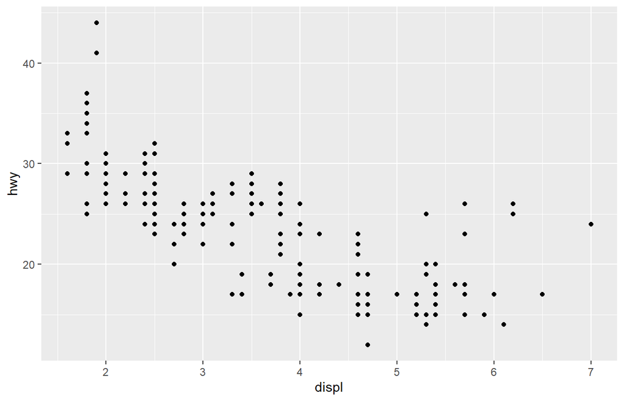

```r
ggplot(data = mpg) +
  geom_point(mapping = aes(x = displ, y = hwy))
```

## 説明

```r
ggplot(data = mpg) +
  geom_point(mapping = aes(x = displ, y = hwy))
```

- `ggplot`: ggplot作るよ
  - `data = mpg`: データは`mpg`で
- `+ geom_point`: 散布図書くよ
  - `mapping = aes(x = displ, y = hwy)`:  
    x軸は`displ`、y軸は`hwy`で

### メモ

```r
help(mpg)
```

- `displ`: エンジン排気量
- `hwy`: 高速道路走行時の燃費

## ルール

```
ggplot(data = <DATA>) +
  <GEOM_FUNCTION>(mapping = aes(<MAPPINGS>))
```

1. `ggplot()`でグラフの土台を作成する
   - 元データとしてデータフレームを受け付ける
2. `geom_***`で何のグラフを書くか決める
   - `aes()`で使う変数を指定する

## 練習問題

1~5

## エステティック

```r
geom_point(mapping = aes( ... ))
```

変数を追加で指定してグラフが持つ情報を増やす

### 使い方

属性=変数 という形で`aes`関数の中に置き、`geom`に`mapping`として渡す

## 散布図の例(color)

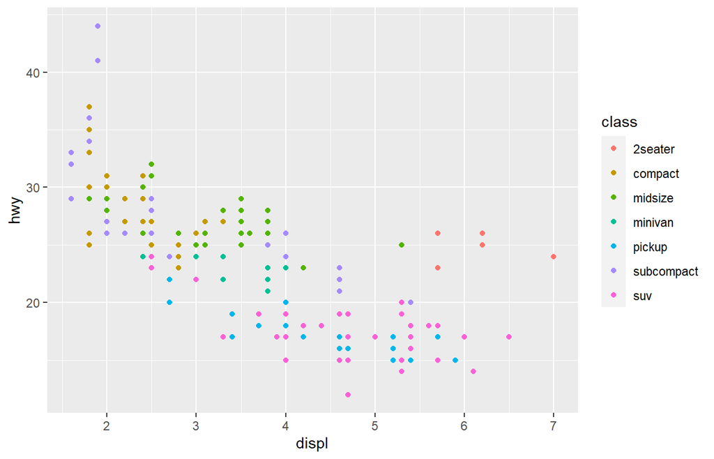

```r
ggplot(data = mpg) +
    geom_point(mapping = aes(x = displ, y = hwy, color = class))
```

## 散布図の例(連続color)

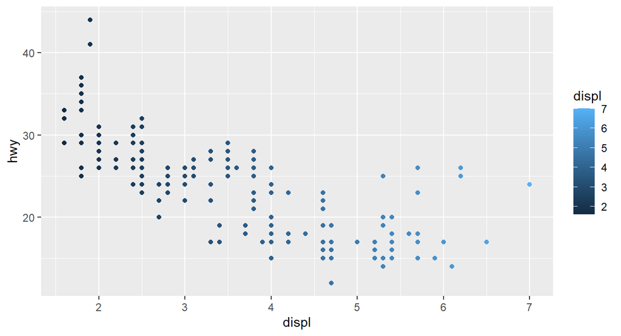

```r
ggplot(data = mpg) +
    geom_point(mapping = aes(x = displ, y = hwy, color = displ))
```

連続変数を指定するとグラデーションになる

## 散布図の例(size)

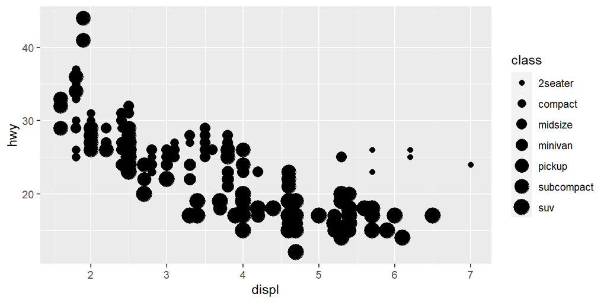

```r
ggplot(data = mpg) +
  geom_point(mapping = aes(x = displ, y = hwy, size = class))
```

- 連続変数のマッピングにお勧め

## 散布図の例(alpha)

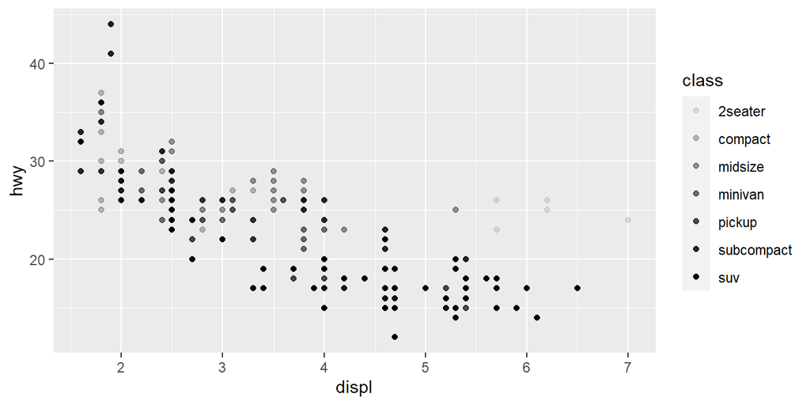

```r
ggplot(data = mpg) +
  geom_point(mapping = aes(x = displ, y = hwy, alpha = class))
```

- `alpha`は連続変数で使うのが推奨されている

## 散布図の例(shape)

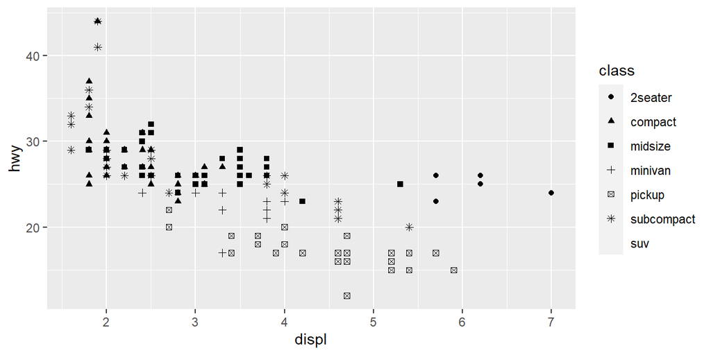

```r
ggplot(data = mpg) +
  geom_point(mapping = aes(x = displ, y = hwy, shape = class))
```

`shape`はデフォルトで６種類までなので`suv`が表示されていない

## エステティックの直接指定

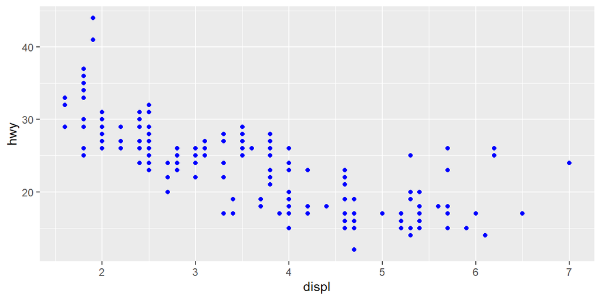

```r
ggplot(data = mpg) +
  geom_point(mapping = aes(x = displ, y = hwy), color = "blue")
```

- 変数でなく直接エステティックを指定することもできる
- その場合は`aes`の外で値を指定する

## 練習問題

1~6

## REPL

Rのコンソールは対話型で一行がプログラムの実行  
(Cやjavascriptはセミコロンまでが実行)

```
ggplot(data = mpg)
  + geom_point(mapping = aes(x = displ, y = hwy))
```

ダメなコードの例(なぜ？)

## ファセット

グラフをカテゴリごとに作る。

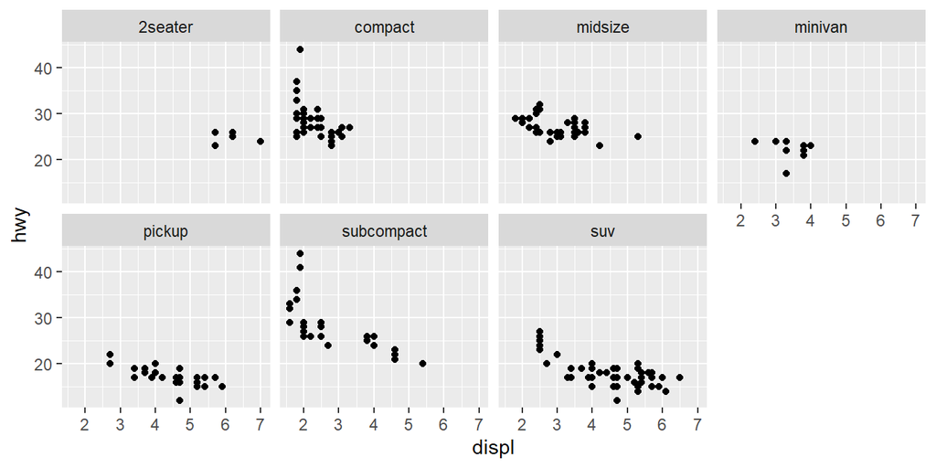

```r
ggplot(data = mpg) +
  geom_point(mapping = aes(x = displ, y = hwy)) +
  facet_wrap(~ class, nrow = 2)
```

## ファセット（２）

二次元配置

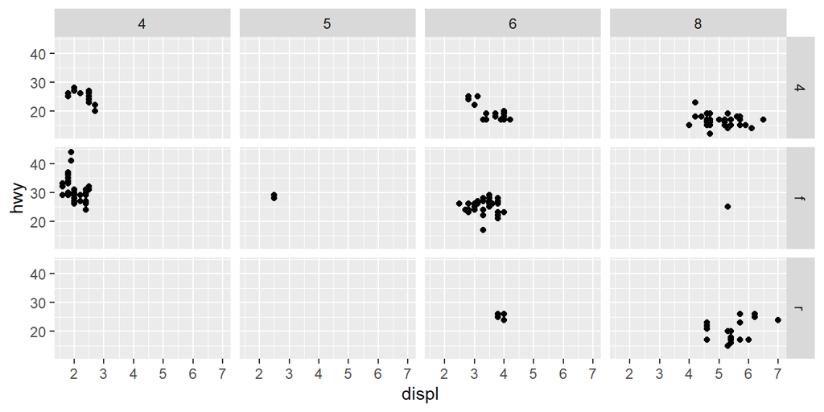

```r
ggplot(data = mpg) +
  geom_point(mapping = aes(x = displ, y = hwy)) +
  facet_grid(drv ~ cyl)
```

## 応用：縦に並べる

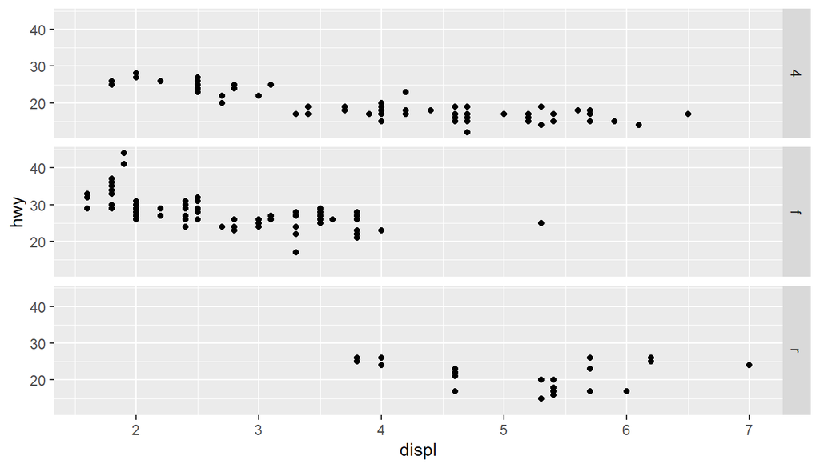

```r
ggplot(data = mpg) +
  geom_point(mapping = aes(x = displ, y = hwy)) +
  facet_grid(drv ~ .)
```

## 練習問題

1~6

## Geom

何のグラフを書くかをコントロールする

- 散布図
- 棒グラフ
- 折れ線グラフ
- 近似曲線

など

## geom_point

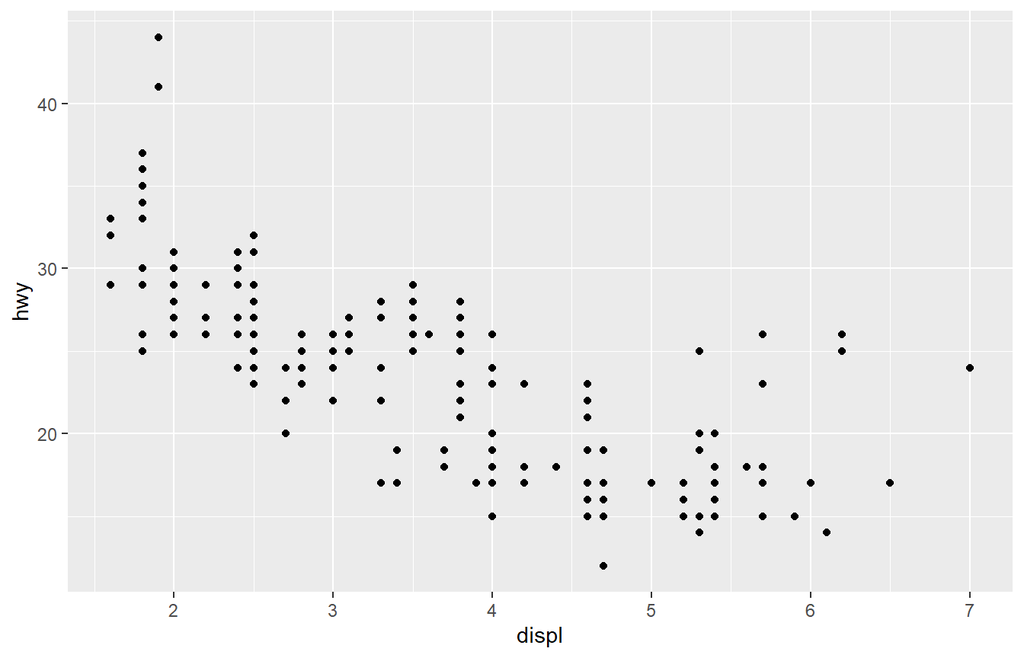

```r
ggplot(data = mpg) +
  geom_point(mapping = aes(x = displ, y = hwy))
```

## geom_smooth

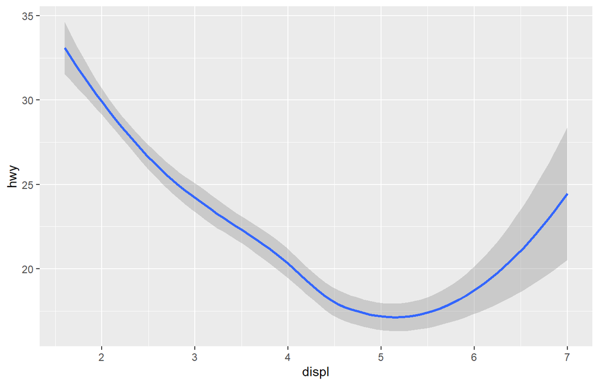

```r
ggplot(data = mpg) +
  geom_smooth(mapping = aes(x = displ, y = hwy))
```

## 重ねる

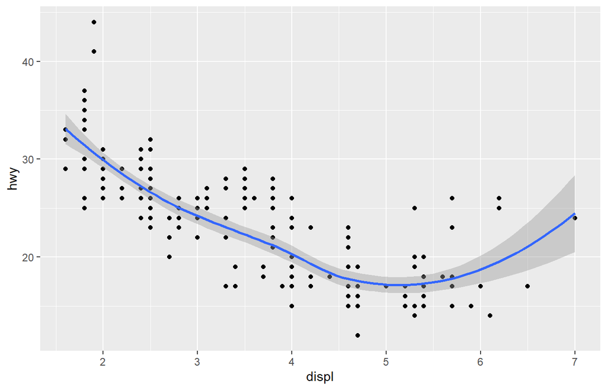

```r
ggplot(data = mpg) +
  geom_point(mapping = aes(x = displ, y = hwy)) +
  geom_smooth(mapping = aes(x = displ, y = hwy))
```

## これでもいいよ

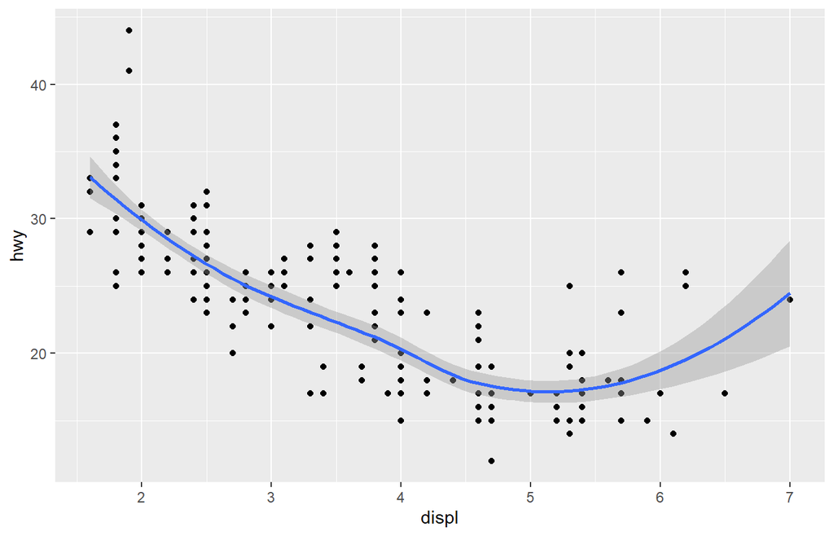

```r
ggplot(data = mpg, mapping = aes(x = displ, y = hwy)) +
  geom_point() +
  geom_smooth()
```

## 必要に応じて個別指定

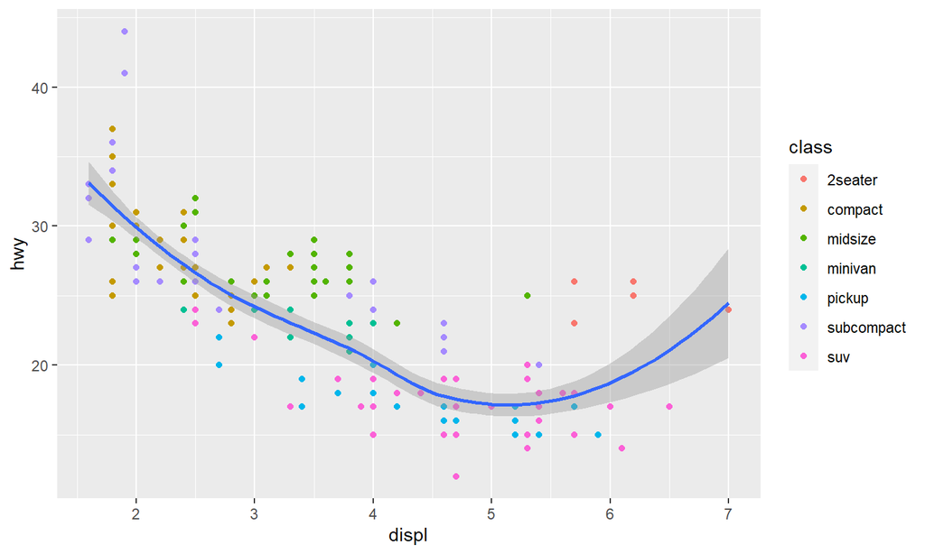

```r
ggplot(data = mpg, mapping = aes(x = displ, y = hwy)) +
  geom_point(mapping = aes(color = class)) +
  geom_smooth()
```

## データを差し替える

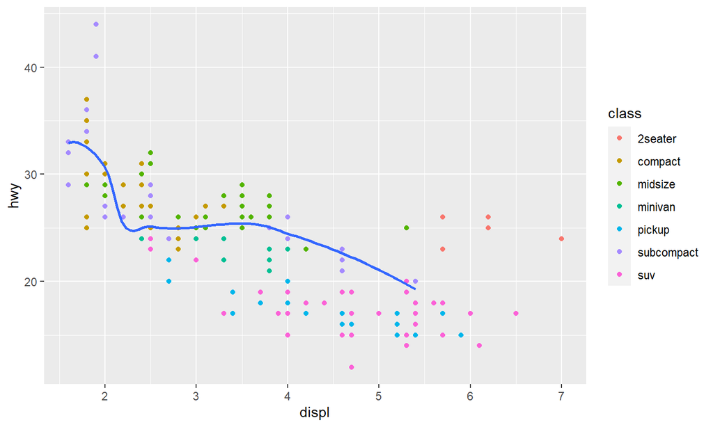

```r
ggplot(data = mpg, mapping = aes(x = displ, y = hwy)) +
  geom_point(mapping = aes(color = class)) +
  geom_smooth(data = filter(mpg, class == "subcompact"), se = FALSE)
```

## 練習問題

1~6

## 棒グラフ

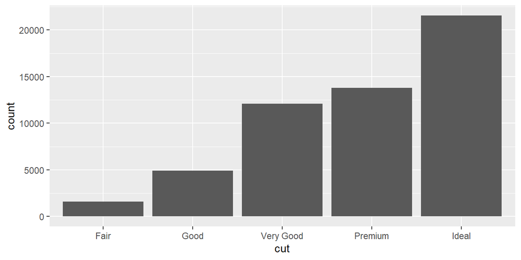

```r
ggplot(data = diamonds) +
  geom_bar(mapping = aes(x = cut))
```

`y`は？

## Stat

書くグラフによってはそのために集計が必要になることがある。

### 例

- ヒストグラム
- 箱ひげ図

`stat`はどのような集計方法でグラフを書くかを制御する。 `geom_bar`の`stat`はcount

## geomとstat

すべてのgeomはデフォルトのstatを持つ。

### 例

- `geom_bar`は`count`
- `geom_point`は`identity`

`stat`を指定すれば上書きして変更できる

```r
ggplot(data = demo) +
  geom_bar(mapping = aes(x = cut, y = freq), stat = "identity")
```

```r
ggplot(data = diamonds) +
  geom_bar(mapping = aes(x = cut, y = ..prop.., group = 1))
```

## stat_summary

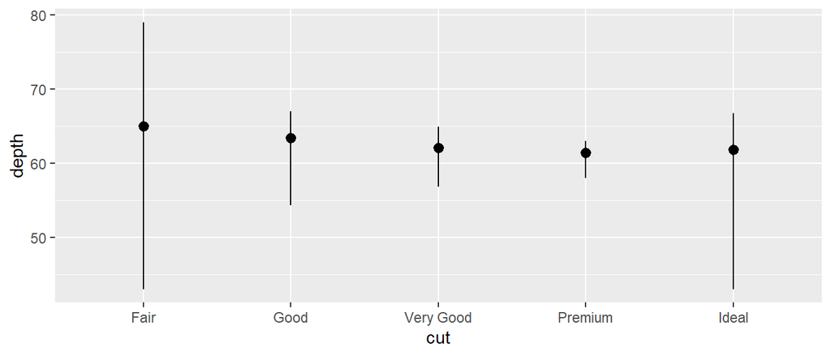

```r
ggplot(data = diamonds) +
  stat_summary(
    mapping = aes(x = cut, y = depth),
    fun.ymin = min,
    fun.ymax = max,
    fun.y = median
  )
```

## 個人的な意見

- `geom`と`stat`はややこしくてわかりにくい
- 基本`geom`を使うようにして`stat`は使わない
  - 唯一`stat_summary`だけは使うことがあるかな・・・
- 基本的に`stat`の操作もしない
  - データを変形して直接集計する
  - `ggplot`の集計は処理が重い

## 練習問題

1~5

## 棒グラフのエステティックcolor

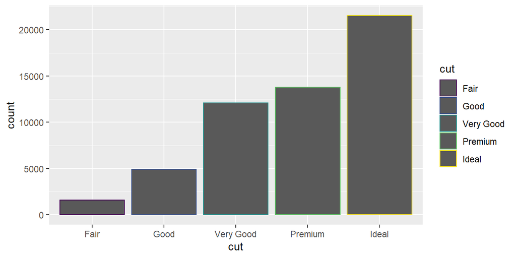

```r
ggplot(data = diamonds) +
  geom_bar(mapping = aes(x = cut, color = cut))
```

colorは周りの線だけ(最初は間違いがち)

## 棒グラフのエステティックfill

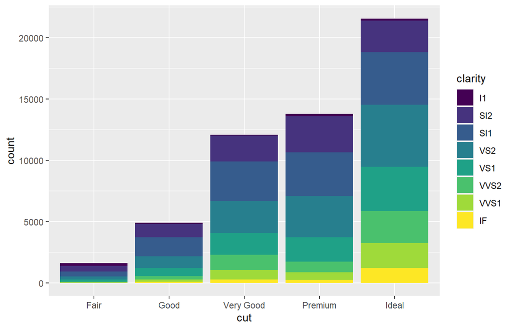

```r
ggplot(data = diamonds) +
  geom_bar(mapping = aes(x = cut, fill = clarity))
```

## ポジション

デフォルトでは積み上げ棒グラフになる

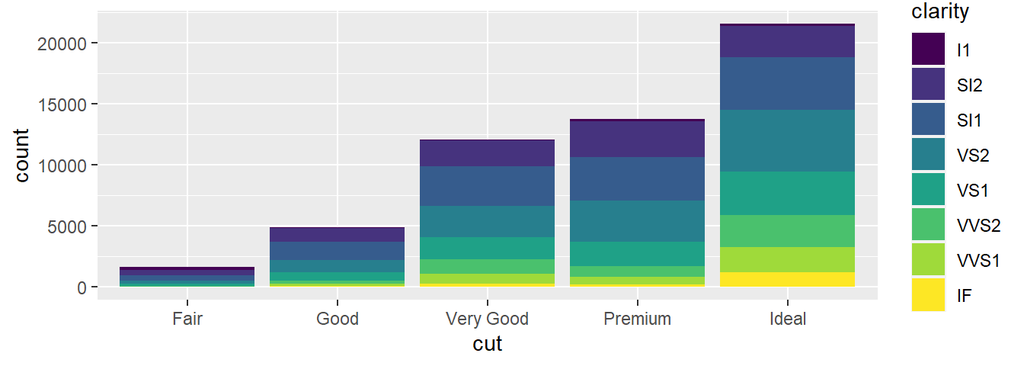

`position`を直接指定することでレイアウト変更

- `position = "stack"`(デフォルト)
- `position = identity`
- `position = fill`
- `position = dodge`

## position identity

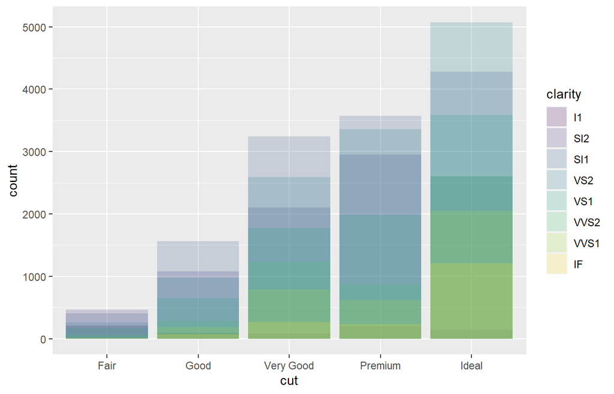

```r
ggplot(data = diamonds, mapping = aes(x = cut, fill = clarity)) +
  geom_bar(alpha = 1/5, position = "identity")
```

## position fill

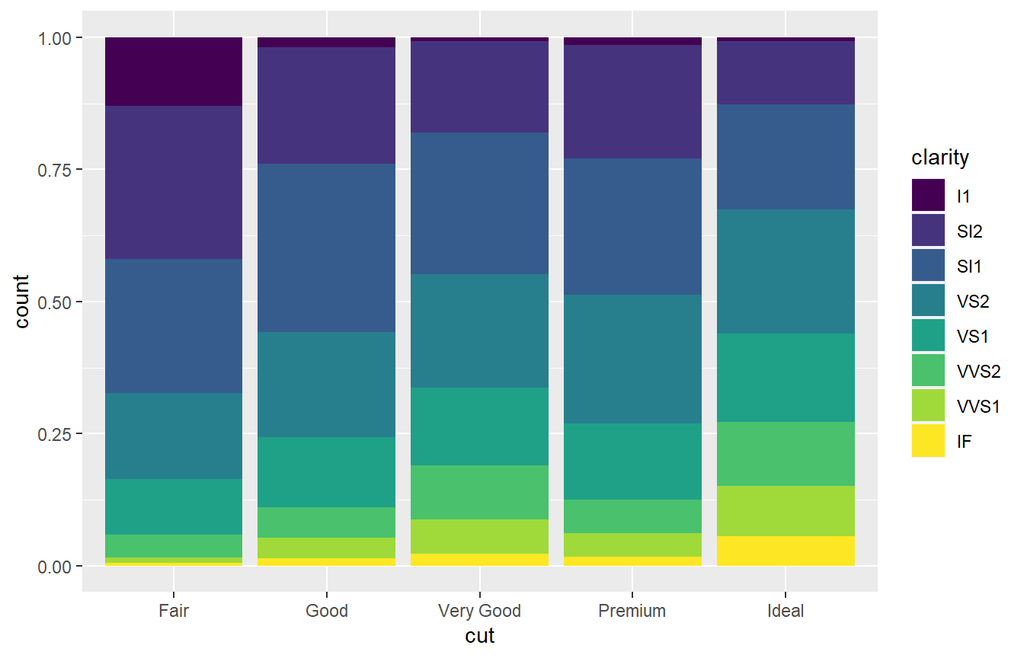

```r
ggplot(data = diamonds) +
  geom_bar(mapping = aes(x = cut, fill = clarity), position = "fill")
```

## position dodge

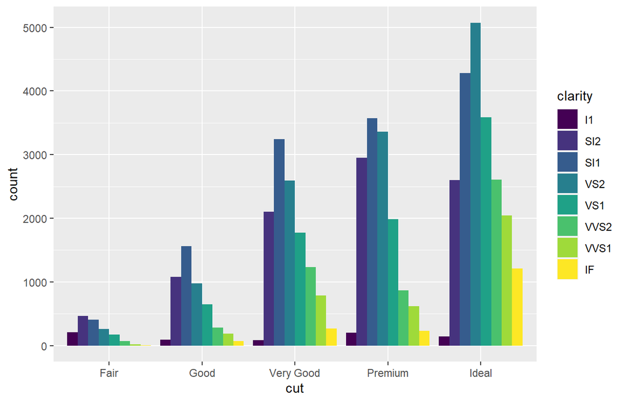

```r
ggplot(data = diamonds) +
  geom_bar(mapping = aes(x = cut, fill = clarity), position = "dodge")
```

## 散布図のposition

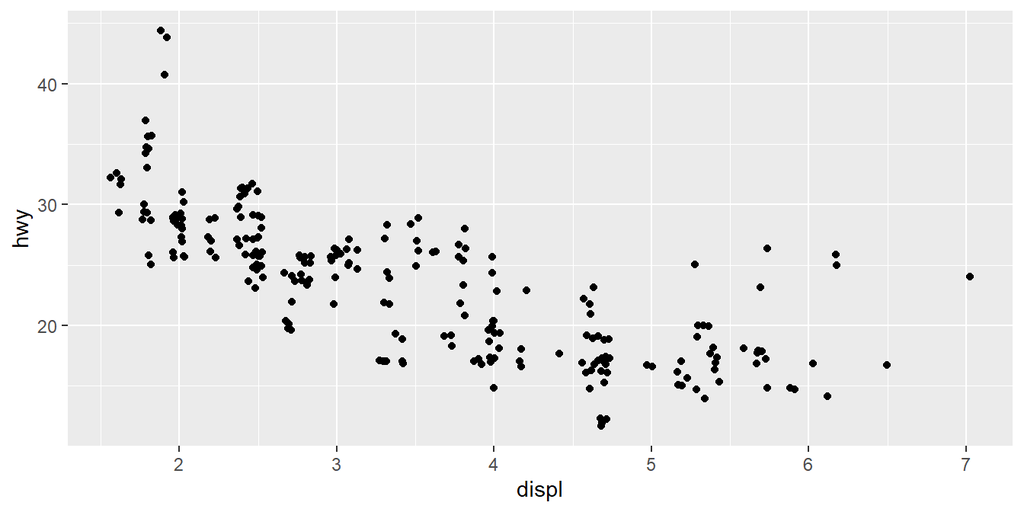

```r
ggplot(data = mpg) +
  geom_point(mapping = aes(x = displ, y = hwy), position = "jitter")
```

散布図の点が重なってしまうときに

## 個人的にはこっちの方が好み

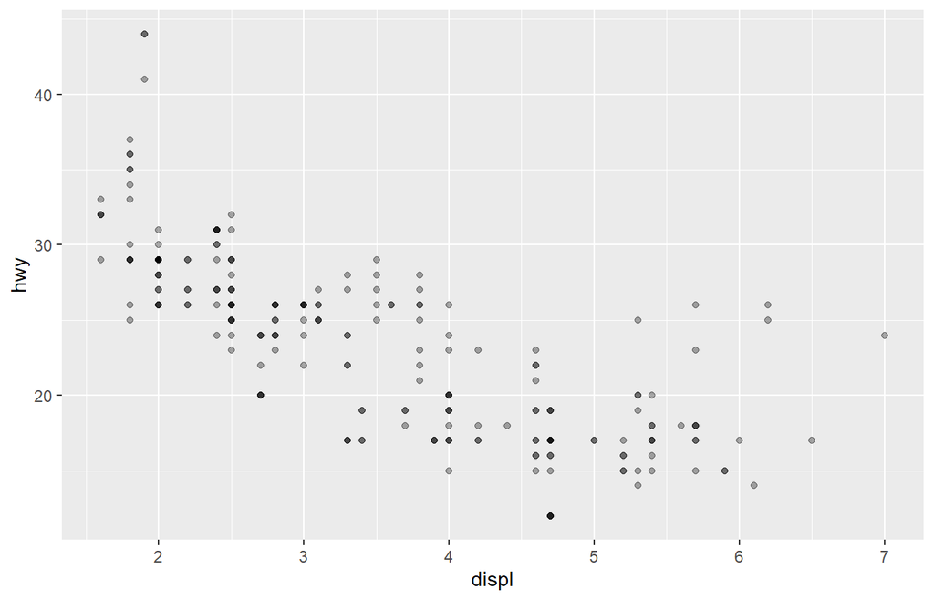

```r
ggplot(data = mpg) +
  geom_point(mapping = aes(x = displ, y = hwy), alpha = 1/3)
```

## 練習問題

1~4

## 座標系

デフォルトの座標系は直交座標

直接指定して変更することもできる

- `coord_flip()`
- `coord_quickmap()`
- `coord_polar()`

## coord_flip

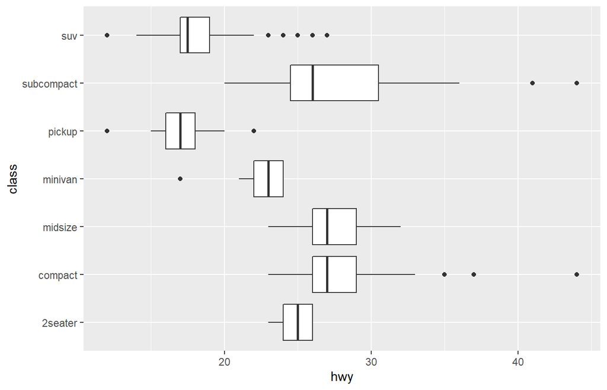

```r
ggplot(data = mpg, mapping = aes(x = class, y = hwy)) +
  geom_boxplot() +
  coord_flip()
```

## 練習問題

1~4

## Grammer of graphicsまとめ

```
ggplot(data = <DATA>) +
  <GEOM_FUNCTION>(
    mapping = aes(<MAPPINGS>),
    stat = <STAT>,
    position = <POSITION>
  ) +
  <COORDINATE_FUNCTION> +
  <FACET_FUNCTION>
```

このシステムですべてのグラフを表現できます！

## お勧めリンク

https://heavywatal.github.io/rstats/ggplot2.html  
よく使う関数たちが整理されている